# eda_report_better

## Transaction Revenue Distribution

Purpose:

To analyze how transaction revenue is distributed and determine whether revenue is generated from many small purchases or a few high-value transactions.

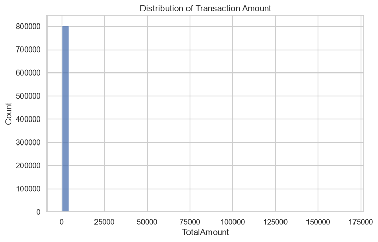

```python
plt.figure(figsize=(8,5))

sns.histplot(df["TotalAmount"], bins=40)

plt.title("Distribution of Transaction Amount")
plt.show()
```

**Observation**

Transaction amounts are extremely right-skewed, with over 800,000 entries clustered near zero while rare outliers stretch the scale up to 175,000.

**Business Insight**

Total revenue is heavily dependent on a massive volume of micro-transactions, leaving the business exposed to high payment processing fees and low operational efficiency.

**Recommendation**

Implement a minimum order threshold for perks like free shipping or priority fulfillment to systematically raise the baseline transaction size.

## Monthly Revenue Trend Analysis

Purpose:

To analyze monthly sales performance over time and identify seasonal trends, growth patterns, and peak sales periods.

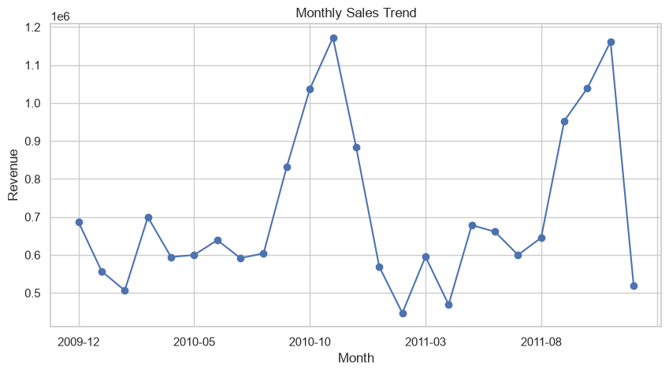

```python
monthly_sales = df.groupby("Month")["TotalAmount"].sum()

monthly_sales.plot(figsize=(10,5), marker="o")

plt.title("Monthly Sales Trend")

plt.ylabel("Revenue")

plt.show()
```

**Observation**

Revenue exhibits severe annual seasonality, characterized by massive peaks exceeding 1.1 million during Q4 and sharp drops below 0.5 million in early Q1.

**Business Insight**

The company is highly reliant on holiday-season demand to meet annual targets, creating extreme cash flow volatility and high operational pressure in Q4.

**Recommendation**

Launch targeted off-season product promotions or subscription models to stabilize recurring revenue and smoothen out the dramatic Q1 slumps.

## Monthly Transaction Volume

Purpose:

To evaluate customer purchasing activity by measuring the number of transactions each month and identifying busy shopping periods.

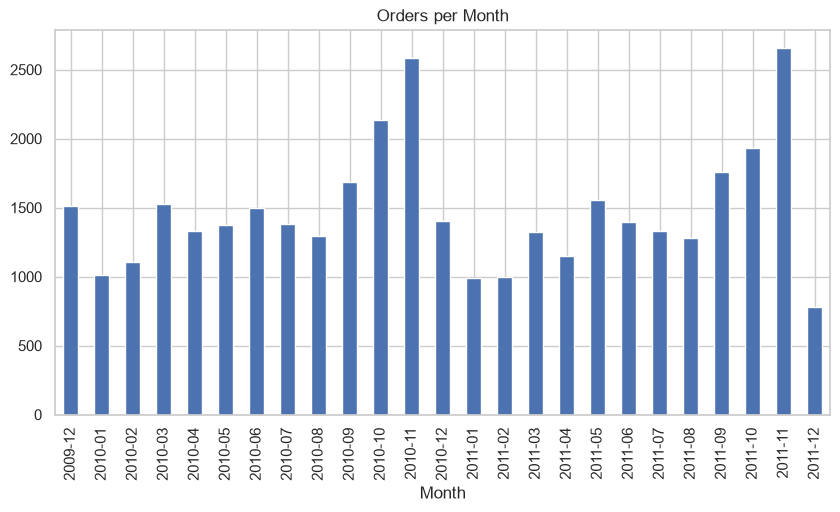

```python
monthly_orders = df.groupby("Month")["Invoice"].nunique()

monthly_orders.plot(kind="bar", figsize=(10,5))

plt.title("Orders per Month")

plt.show()
```

**Observation**

Order volume shows distinct annual cyclicality, surging to major peaks above 2,500 orders every November before dropping sharply in December.

**Business Insight**

Demand is highly concentrated in a two-month peak window, indicating that processing capacity and logistics pipelines face immense strain for a very short period each year.

**Recommendation**

Optimize inventory and scale up logistics capacity proactively in September to prevent stockouts and shipping bottlenecks during the high-volume November surge.

## Top 10 Best-Selling Products by Quantity

Purpose:

To identify the products with the highest sales volume and understand which items are most popular among customers.

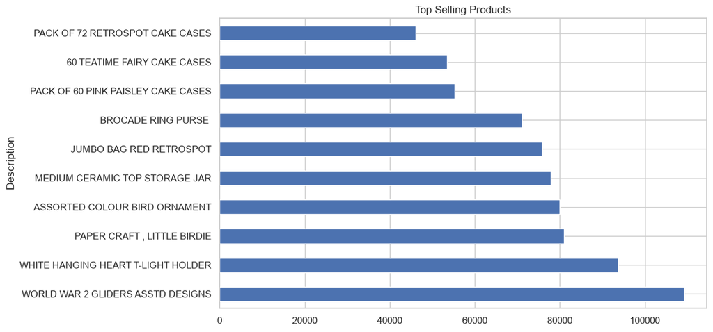

```python
top_products = (
    df.groupby("Description")["Quantity"]
      .sum()
      .sort_values(ascending=False)
      .head(10)
)

top_products.plot(kind="barh", figsize=(10,6))

plt.title("Top Selling Products")

plt.show()
```

**Observation**

"WORLD WAR 2 GLIDERS" is the top-selling item by volume, leading a top-10 list heavily dominated by low-cost novelty toys, crafting supplies, and small home decor items.

**Business Insight**

High volume is driven entirely by cheap, impulse-buy products, meaning the core revenue engine is highly vulnerable to supply chain disruptions or manufacturing cost increases for these specific goods.

**Recommendation**

Create curated party or home decor bundles that pair these high-volume impulse items with higher-margin accessories to systematically increase average order value.

## Top 10 Revenue-Generating Products

Purpose:

To identify the products contributing the highest revenue and determine which products drive business profitability.

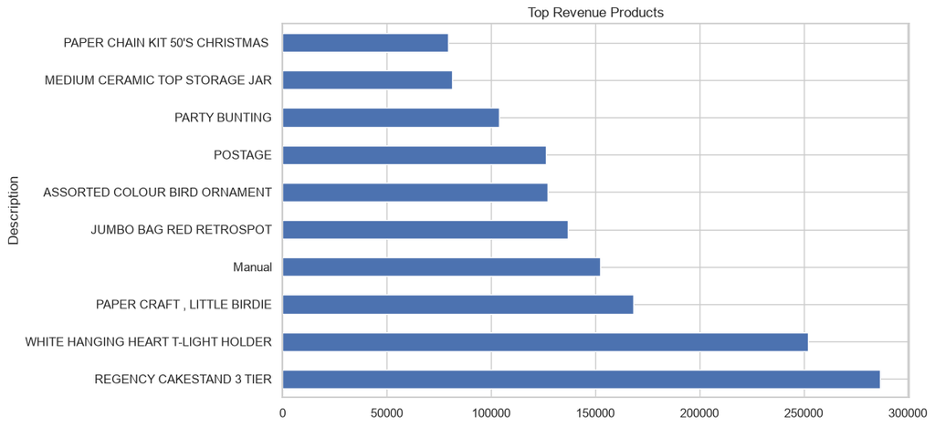

```python
top_revenue = (
    df.groupby("Description")["TotalAmount"]
      .sum()
      .sort_values(ascending=False)
      .head(10)
)

top_revenue.plot(kind="barh", figsize=(10,6))

plt.title("Top Revenue Products")

plt.show()
```

**Observation**

"REGENCY CAKESTAND 3 TIER" and "WHITE HANGING HEART T-LIGHT HOLDER" are the clear revenue leaders, significantly outperforming the remaining top-10 products.

**Business Insight**

High-value home and party hosting items drive a disproportionate share of the total revenue, identifying them as critical anchors for financial growth.

**Recommendation**

Allocate more marketing budget toward high-intent ad campaigns for these top two revenue drivers to maximize return on ad spend (ROAS).

## Top 10 Customers by Revenue

Purpose:

To identify high-value customers who contribute the largest share of revenue and support customer retention strategies.

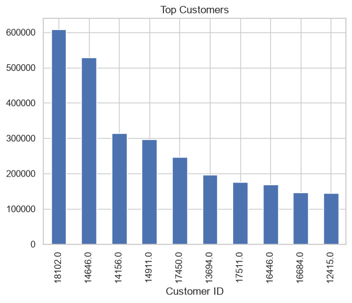

```python
top_customers = (
    df.groupby("Customer ID")["TotalAmount"]
      .sum()
      .sort_values(ascending=False)
      .head(10)
)

top_customers.plot(kind="bar")

plt.title("Top Customers")

plt.show()
```

**Observation**

Customer IDs 18102.0 and 14646.0 are the dominant revenue contributors, with each generating well over 500,000 in total sales.

**Business Insight**

The business is heavily exposed to client concentration risk, where losing just one or two top-tier accounts would severely impact total revenue.

**Recommendation**

Assign dedicated account managers and offer exclusive contract pricing to these top two VIP clients to maximize customer retention.

## Revenue by Country Analysis

Purpose:

To compare sales performance across countries and identify key geographical markets for the business.

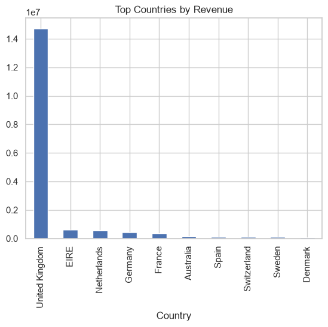

```python
country_sales = (
    df.groupby("Country")["TotalAmount"]
      .sum()
      .sort_values(ascending=False)
      .head(10)
)

country_sales.plot(kind="bar")

plt.title("Top Countries by Revenue")

plt.show()
```

**Observation**

The United Kingdom is the absolute dominant revenue generator, contributing over 14 million, while all other international markets remain below 1 million.

**Business Insight**

The company faces extreme geographic concentration risk, making its entire financial stability highly dependent on the economic health and regulations of a single market.

**Recommendation**

Allocate localized marketing budgets and set up dedicated international fulfillment hubs to aggressively scale presence in high-potential European markets like EIRE, Netherlands, and Germany.

## Correlation Heatmap of Numerical Features

Purpose:

To examine relationships between numerical variables and identify factors that influence revenue and sales performance.

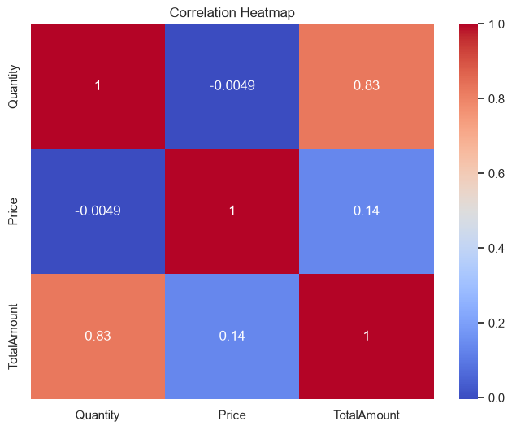

```python
plt.figure(figsize=(8,6))

sns.heatmap(
    df[["Quantity","Price","TotalAmount"]].corr(),
    annot=True,
    cmap="coolwarm"
)

plt.title("Correlation Heatmap")

plt.show()
```

**Observation**

TotalAmount shares a strong positive correlation (0.83) with Quantity, but a very weak correlation (0.14) with Price, while Price and Quantity show almost zero correlation (-0.0049).

**Business Insight**

Total transaction revenue is heavily driven by transaction volume rather than individual unit pricing, making order size the primary lever for financial growth.

**Recommendation**

Focus commercial strategies on increasing order volumes through bulk discounting, bundling, and multi-unit promotions rather than relying on price increases to grow revenue.

## Revenue by Day of the Week

Purpose:

To determine which weekdays generate the highest sales and support operational planning and promotional scheduling.

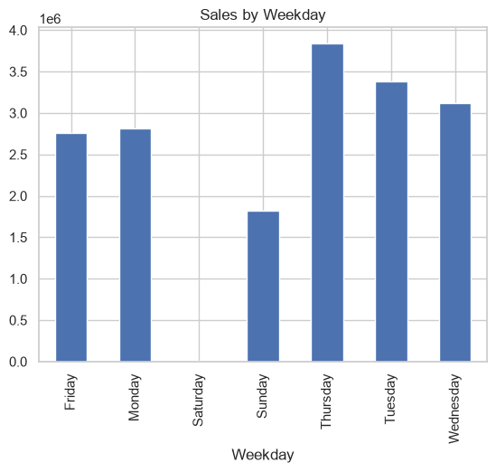

```python
weekday_sales = df.groupby("Weekday")["TotalAmount"].sum()

weekday_sales.plot(kind="bar")

plt.title("Sales by Weekday")

plt.show()
```

**Observation**

Thursday is the peak sales day reaching nearly 3.8 million, while Saturday shows zero revenue and Sunday reflects the lowest active sales volume.

**Business Insight**

The business operates on a strict weekday-dominant or B2B purchasing cycle, leading to completely offline operations on Saturdays and severely underutilized capacity on Sundays.

**Recommendation**

Launch automated weekend-only email promotions or flash sales to activate retail buyer demand and capture revenue during these dormant weekend gaps.

## Revenue by Hour of the Day

Purpose:

To identify peak shopping hours and optimize staffing, customer support, and marketing campaigns.

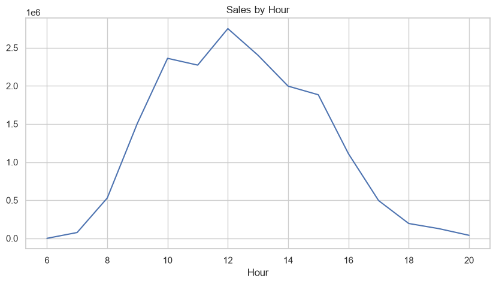

```python
hour_sales = df.groupby("Hour")["TotalAmount"].sum()

hour_sales.plot(figsize=(10,5))

plt.title("Sales by Hour")

plt.show()
```

**Observation**

Sales ramp up sharply in the morning to peak at 12:00 PM (midday) with over 2.7 million in revenue, before experiencing a steady, continuous decline toward the evening.

**Business Insight**

Purchasing activity is highly concentrated during core midday and lunch hours (10 AM to 3 PM), suggesting that buyers highly favor shopping during their standard daytime breaks.

**Recommendation**

Schedule all push notifications, email campaigns, and customer service live-chat staffing to peak between 10 AM and 1 PM to capture maximum active consumer engagement.

## Average Order Value (AOV) Trend

Purpose:

To analyze changes in average customer spending over time and identify periods of high-value purchasing behavior.

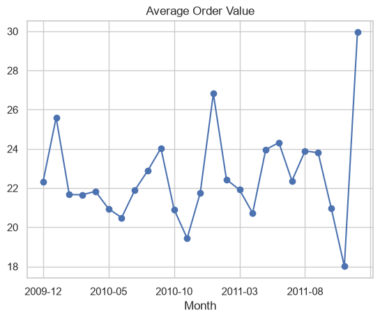

```python
avg_order = df.groupby("Month")["TotalAmount"].mean()

avg_order.plot(marker="o")

plt.title("Average Order Value")

plt.show()
```

**Observation**

Average Order Value generally fluctuates between 20 and 26 before plunging to a historic low of 18 and instantly spiking to an all-time high of 30 in the final month.

**Business Insight**

The sudden massive surge at the end indicates either a highly concentrated holiday bulk-buying shift or a highly successful upselling initiative that radically expanded transaction sizes.

**Recommendation**

Reverse-engineer the exact product mix, discounting rules, and customer segments from that final peak month to build a repeatable strategy for year-round high-value orders.

## Top Products by Sales Quantity (SKU Performance)

Purpose:

To evaluate product-level performance using stock codes and identify inventory items requiring priority management.

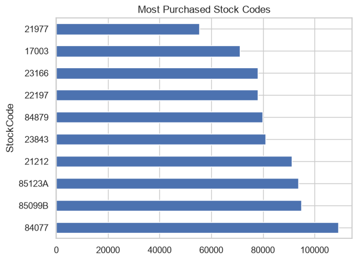

```python
top_stock = (
    df.groupby("StockCode")["Quantity"]
      .sum()
      .sort_values(ascending=False)
      .head(10)
)

top_stock.plot(kind="barh")

plt.title("Most Purchased Stock Codes")

plt.show()
```

**Observation**

Stock Code 84077 is the most frequently purchased item, leading a top-10 list where the top three codes each exceed 90,000 units in total volume.

**Business Insight**

High reliance on a narrow set of fast-moving stock codes indicates that inventory health and warehouse throughput are heavily dependent on just a few core SKUs.

**Recommendation**

Establish safety stock thresholds and automated reorder triggers specifically for these top 10 SKUs to completely eliminate the risk of stockouts on high-demand items.

## Transaction Revenue Box Plot (Outlier Analysis)

Purpose:

To detect outliers in transaction revenue, understand revenue variability, and identify unusually large purchases.

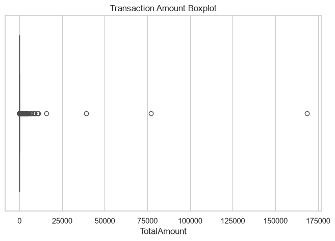

```python
plt.figure(figsize=(8,5))

sns.boxplot(x=df["TotalAmount"])

plt.title("Transaction Amount Boxplot")

plt.show()
```

**Observation**

The boxplot collapses tightly near zero, indicating a heavily compressed interquartile range with massive, isolated positive outliers reaching up to 168,000.

**Business Insight**

Standard retail operational metrics are completely warped by rare, hyper-large wholesale transactions that obscure the baseline realities of everyday customer behavior.

**Recommendation**

Segment transactional data by isolating everything above 15,000 into a distinct B2B reporting channel to allow for accurate retail trend analysis.

## Key Business Insights

- Volume-Driven Revenue: Low-cost, high-quantity item sales drive growth over premium unit pricing.
- Severe Concentration Risk: Financial stability relies entirely on the UK market and two VIP clients.
- Extreme Holiday Seasonality: Sales peak massively in November and drop sharply during Q1.
- Midday Weekday Purchasing: Transaction traffic concentrates on weekdays, peaking sharply at midday.
- Outlier-Warped Metrics: Rare, massive wholesale orders heavily distort standard retail averages.

## Conclusion

The business operates a highly successful, high-volume transactional model anchored by low-cost novelty goods, a dominant UK presence, and strong Q4 seasonal demand. However, this success is heavily reliant on a small group of high-volume wholesale outliers and just two key VIP clients, introducing significant concentration and operational risks. Moving forward, the company can sustain its growth by diversifying into international markets, formalizing B2B contracts, and shifting its operational scheduling to match its clear midday and weekday customer traffic peaks.